# Analysis of Why Patients Miss Their Scheduled Medical Appointments

## Exploratory Data Analysis

Here we wanted to see what kind of correlations we could take out of the data to hopefully figure out if certain health conditions make people more prone to missing a medical appointment. The three most prominent medical conditions that were presented in the dataset include: Hypertension, Diabetes and Alcoholism. We decided to ignore the Handicap column because there was not a sufficient amount of data to make it meaningful for analysis. We wanted to compare whether there were any differences between patients who did and did not show up for their appointments so we plotted plots for both of the groups.

STANDARDIZING THE DATA

```python
std_age = appts.groupby('Gender')['Age'].std()
avg_age = appts.groupby('Gender')['Age'].mean()
stdized = []

for index, row in appts.iterrows():
    s = std_age.loc[row['Gender']]
    var = (row['Age'] - avg_age.loc[row['Gender']]) / s
    stdized.append(var)
appts['std_age'] = stdized
appts.head()
```

|  | Gender | ScheduledDay | AppointmentDay | Age | Scholarship | Hipertension | Diabetes | Alcoholism | SMS_received | No-show | ScheduledSeason | AppointmentSeason | std_age |
| --- | --- | --- | --- | --- | --- | --- | --- | --- | --- | --- | --- | --- | --- |
| 0 | F | 2016-04-29 18:38:08 | 2016-04-29 | 62 | 0 | 1 | 0 | 0 | 0 | No | Autumn | Autumn | 1.042914 |
| 1 | M | 2016-04-29 16:08:27 | 2016-04-29 | 56 | 0 | 0 | 0 | 0 | 0 | No | Autumn | Autumn | 0.911109 |
| 2 | F | 2016-04-29 16:19:04 | 2016-04-29 | 62 | 0 | 0 | 0 | 0 | 0 | No | Autumn | Autumn | 1.042914 |
| 3 | F | 2016-04-29 17:29:31 | 2016-04-29 | 8 | 0 | 0 | 0 | 0 | 0 | No | Autumn | Autumn | -1.394433 |
| 4 | F | 2016-04-29 16:07:23 | 2016-04-29 | 56 | 0 | 1 | 1 | 0 | 0 | No | Autumn | Autumn | 0.772098 |

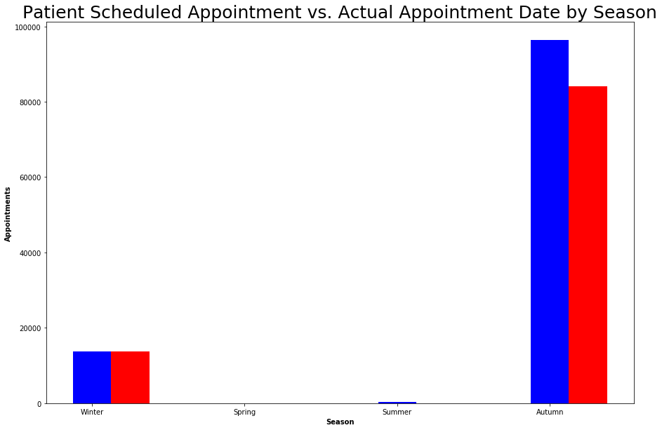

```python
schedseason = appts[['ScheduledSeason', 'AppointmentSeason']]
countSched = {'Winter': 0, 'Spring': 0, 'Summer': 0, 'Autumn': 0}
countAppoint = {'Winter': 0, 'Spring': 0, 'Summer': 0, 'Autumn': 0}

for i, row in schedseason.iterrows():
    if row['ScheduledSeason'] == 'Winter':
        countSched['Winter'] = countSched.get('Winter', 0) + 1
    if row['AppointmentSeason'] == 'Winter':
        countAppoint['Winter'] = countAppoint.get('Winter', 0) + 1
    if row['ScheduledSeason'] == 'Spring':
        countSched['Spring'] = countSched.get('Spring', 0) + 1
    if row['AppointmentSeason'] == 'Spring':
        countAppoint['Spring'] = countAppoint.get('Spring', 0) + 1
    if row['ScheduledSeason'] == 'Summer':
        countSched['Summer'] = countSched.get('Summer', 0) + 1
    if row['AppointmentSeason'] == 'Summer':
        countAppoint['Summer'] = countAppoint.get('Summer', 0) + 1
    if row['ScheduledSeason'] == 'Autumn':
        countSched['Autumn'] = countSched.get('Autumn', 0) + 1
    if row['AppointmentSeason'] == 'Autumn':
        countAppoint['Autumn'] = countAppoint.get('Autumn', 0) + 1

barWidth = .25
fig = plt.figure(figsize=(15,10))

r1 = range(len(countSched))
r2 = [x + barWidth for x in r1]
plt.bar(r1, list(countSched.values()), color='b', width=barWidth, align = 'center')
plt.bar(r2, list(countAppoint.values()), color='r', width=barWidth, align = 'center')
plt.xlabel('Season', fontweight='bold')
plt.ylabel('Appointments', fontweight='bold')
plt.title("Patient Scheduled Appointment vs. Actual Appointment Date by Season", fontsize='25')
plt.xticks(range(len(countSched)), list(countSched.keys()))
plt.show()
```

Initially, we thought that the season would have some kind of impact on whether patients would attend their appointments such as changing season with cold and flu season. However, upon further analysis, we found that a majority of the appointments were scheduled during the Brazil's Autumn season. If we had a larger dataset then this would prove to be a more reliable reason for patient attendance, but this dataset did not account for the rest of the year. This unfortunately may skew our data a bit since the data will mostly consist of fall appointments.

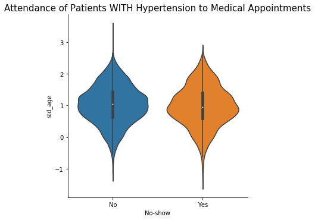

```python
hibloodpressure = appts[appts['Hipertension'] == 1]
fig = plt.figure(figsize=(15,10))
sns.catplot(x='No-show',y='std_age',data= hibloodpressure,kind="violin",order=['No','Yes'])
plt.title("Attendance of Patients WITH Hypertension to Medical Appointments", fontsize=15)
plt.show()
```

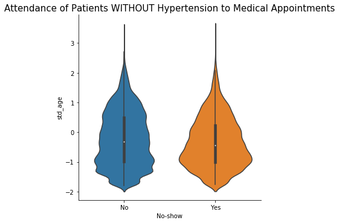

```python
hibloodpressure = appts[appts['Hipertension'] == 0]
fig = plt.figure(figsize=(15,10))
sns.catplot(x='No-show',y='std_age',data= hibloodpressure,kind="violin",order=['No','Yes'])
plt.title("Attendance of Patients WITHOUT Hypertension to Medical Appointments", fontsize=15)
plt.show()
```

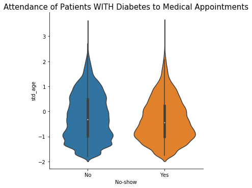

```python
diabetes = appts[appts['Diabetes'] == 1]
fig = plt.figure(figsize=(15,10))
sns.catplot(x='No-show',y='std_age',data= hibloodpressure,kind="violin",order=['No','Yes'])
plt.title("Attendance of Patients WITH Diabetes to Medical Appointments", fontsize=15)
plt.show()
```

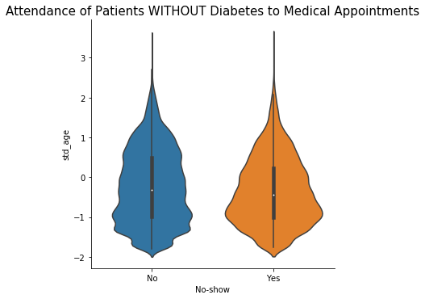

```python
diabetes = appts[appts['Diabetes'] == 0]
fig = plt.figure(figsize=(15,10))
sns.catplot(x='No-show',y='std_age',data= hibloodpressure,kind="violin",order=['No','Yes'])
plt.title("Attendance of Patients WITHOUT Diabetes to Medical Appointments", fontsize=15)
plt.show()
```

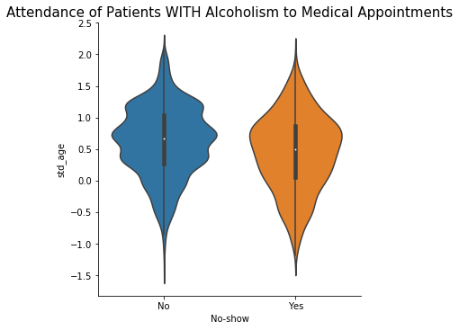

```python
alcoholism = appts[appts['Alcoholism'] == 1]
fig = plt.figure(figsize=(15,10))
sns.catplot(x='No-show',y='std_age',data= alcoholism,kind="violin")
plt.title("Attendance of Patients WITH Alcoholism to Medical Appointments",fontsize=15)
plt.show()
```

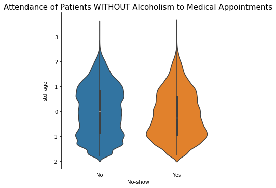

```python
alcoholism = appts[appts['Alcoholism'] == 0]
fig = plt.figure(figsize=(15,10))
sns.catplot(x='No-show',y='std_age',data= alcoholism,kind="violin")
plt.title("Attendance of Patients WITHOUT Alcoholism to Medical Appointments",fontsize=15)
plt.show()
```

```python
std_age = appts.groupby('Gender')['Age'].std()
avg_age = appts.groupby('Gender')['Age'].mean()
stdized = []

for index, row in appts.iterrows():
    s = std_age.loc[row['Gender']]
    var = (row['Age'] - avg_age.loc[row['Gender']]) / s
    stdized.append(var)
appts['std_age'] = stdized
appts.head()
```

|  | Gender | ScheduledDay | AppointmentDay | Age | Scholarship | Hipertension | Diabetes | Alcoholism | SMS_received | No-show | ScheduledSeason | AppointmentSeason | std_age |
| --- | --- | --- | --- | --- | --- | --- | --- | --- | --- | --- | --- | --- | --- |
| 0 | F | 2016-04-29 18:38:08 | 2016-04-29 | 62 | 0 | 1 | 0 | 0 | 0 | No | Autumn | Autumn | 1.042914 |
| 1 | M | 2016-04-29 16:08:27 | 2016-04-29 | 56 | 0 | 0 | 0 | 0 | 0 | No | Autumn | Autumn | 0.911109 |
| 2 | F | 2016-04-29 16:19:04 | 2016-04-29 | 62 | 0 | 0 | 0 | 0 | 0 | No | Autumn | Autumn | 1.042914 |
| 3 | F | 2016-04-29 17:29:31 | 2016-04-29 | 8 | 0 | 0 | 0 | 0 | 0 | No | Autumn | Autumn | -1.394433 |
| 4 | F | 2016-04-29 16:07:23 | 2016-04-29 | 56 | 0 | 1 | 1 | 0 | 0 | No | Autumn | Autumn | 0.772098 |

Now we want to analyze SMS_received using our standarized variable. This will allow us to determine if a patient receiving a text reminder impacts if they will show up to an appointment.

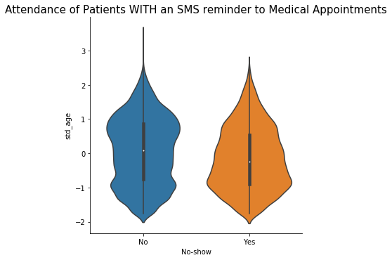

```python
sms1 = appts[appts['SMS_received'] == 1]
fig = plt.figure(figsize=(15,10))
sns.catplot(x='No-show', y='std_age', data=sms1, kind="violin", order=['No', 'Yes'])
plt.title("Attendance of Patients WITH an SMS reminder to Medical Appointments", fontsize=15)
plt.show()
```

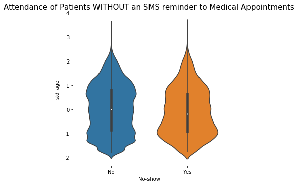

```python
sms0 = appts[appts['SMS_received'] == 0]
fig = plt.figure(figsize=(15,10))
sns.catplot(x='No-show', y='std_age', data=sms0, kind="violin")
plt.title("Attendance of Patients WITHOUT an SMS reminder to Medical Appointments", fontsize=15)
plt.show()
```

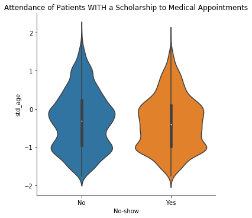

```python
scholarship = appts[appts['Scholarship'] == 1]
fig = plt.figure(figsize=(15,10))
sns.catplot(x='No-show',y='std_age',data= scholarship, kind="violin",order=['No','Yes'])
plt.title("Attendance of Patients WITH a Scholarship to Medical Appointments")
plt.show()
```

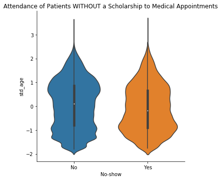

```python
scholarship = appts[appts['Scholarship'] == 0]
fig = plt.figure(figsize=(15,10))
sns.catplot(x='No-show',y='std_age',data= scholarship, kind="violin",order=['No','Yes'])
plt.title("Attendance of Patients WITHOUT a Scholarship to Medical Appointments")
plt.show()
```

Here we investigate the likeliness of a patient attending his or her medical appointment due to his or her scholarship. When the data is talking about the scholarship, it means if he or she receives a scholarship then he or she is less fortunate and needs the scholarship and if he or she is fortunate then he or she will not require the scholarship. From the plots of the data, it seems that people who are more poor are more likely to miss his or her appointment.

## Hypothesis Testing and Machine Learning

```python
for index, row in appts.iterrows():
    if row['No-show'] == 'No':
        appts.at[index, 'noshow_val'] = np.int64(0)
    else:
        appts.at[index, 'noshow_val'] = np.int64(1)

x = appts['noshow_val'].values.reshape(-1,1)
y = appts['std_age'].values.reshape(-1,1)
reg = LinearRegression().fit(x, y)
coef = reg.coef_
intercept = reg.intercept_
print(coef, intercept)
```

```
[[-0.15256551]] [0.03080794]
```

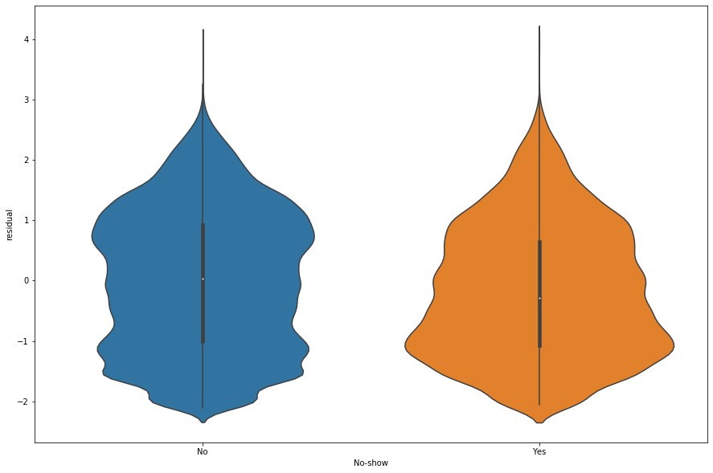

```python
est = []
for x in appts['std_age'].values:
    est.append(reg.predict(x.reshape(-1,1))[0][0])

appts["est"] = est
appts["residual"] = appts["std_age"] - appts["est"]
fig = plt.figure(figsize=(15,10))
sns.violinplot(x="No-show", y="residual", data=appts)
```

This residual created above from the linear regression prediction compared to no-shows, so the regression predicted the ages of no-shows and the distribution seems to show that younger people are more likely to be a no-show.

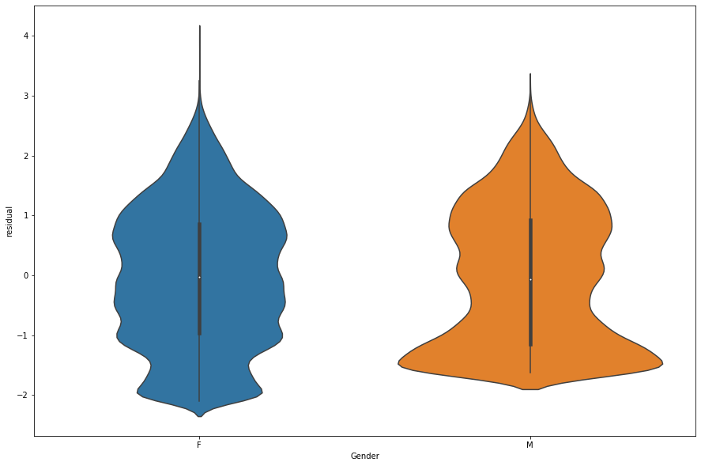

```python
fig = plt.figure(figsize=(15,10))
sns.violinplot(x="Gender", y="residual", data=appts)
```

Here we can see some discrepancy between the two genders interaction with the residual, so let's run a linear regression to see if we need an interaction term between Age and Gender.

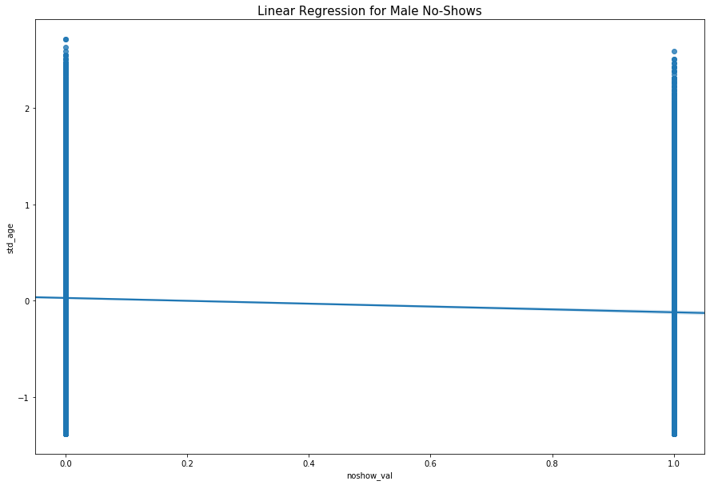

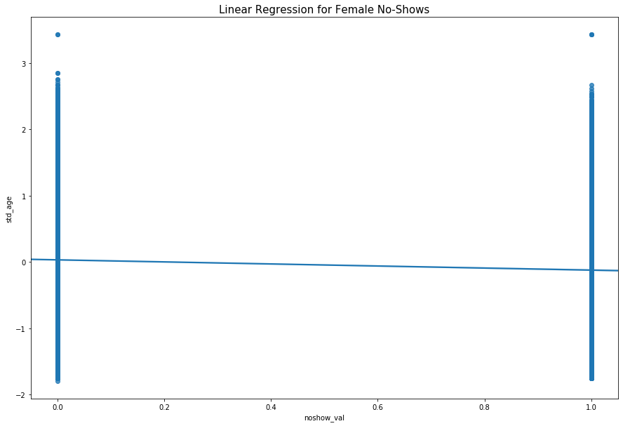

```python
temp = appts.groupby('Gender')
genders = dict(list(temp))

fig = plt.figure(figsize=(15,10))
male = genders['M']
ax = sns.regplot(x="noshow_val", y="std_age", data=male)
plt.title("Linear Regression for Male No-Shows", fontsize=15)
plt.show()

fig = plt.figure(figsize=(15,10))
female = genders['F']
ax = sns.regplot(x="noshow_val", y="std_age", data=female)
plt.title("Linear Regression for Female No-Shows", fontsize=15)
plt.show()
```

Based on this plot it is not necessary to create an interaction term between age and gender since the standardization from earlier in the project has made the two regressions consistent.

## Predicting the Likelihood of Patients not going to their Doctor's Apointments

The model that we are going to use in order to predict the likelihood of patients not attending their appointments based on gender, prexisting health conditions(Diabetes and Hypertension), alcoholism, text messages(recieving a text message about their doctors appointment), and their income level(scholarship). Using linear regression we will need to calculate the ratios of missing appointments.

Here, we create a new dataframe with which we use the factors from our Exploratory Data Analysis, in order to create a ratio that we will use in order to predict the likelihood of patients not showing up to their appointments.

```python
# Add a column to the dataframe representing number of appointments
appts['appt_val'] = np.int64(1)

# No-Show Factors: Gender, Scholarship, Hipertension, Diabetes, Alcoholism, Handcap, SMS_received
# Create dataframe to sum up No-Shows and Number of appointments based on these factors
factors = appts.groupby(['Gender', 'Scholarship', 'Hipertension', 'Diabetes', 'Alcoholism', 'SMS_received'], \
            as_index=False)['noshow_val', 'appt_val'].sum()

# Creating the No-Show ratio based on number of appointments missed vs number of appointments of that type
factors['noshow_ratio'] = pd.to_numeric(factors['noshow_val']) / pd.to_numeric(factors['appt_val'])

for index, row in factors.iterrows():
    if row['Gender'] == 'M':
        factors.at[index, 'Gender'] = np.int64(0)
    else:
        factors.at[index, 'Gender'] = np.int64(1)

factors.head()
```

|  | Gender | Scholarship | Hipertension | Diabetes | Alcoholism | SMS_received | noshow_val | appt_val | noshow_ratio |
| --- | --- | --- | --- | --- | --- | --- | --- | --- | --- |
| 0 | 1 | 0 | 0 | 0 | 0 | 0 | 5273.0 | 31532 | 0.167227 |
| 1 | 1 | 0 | 0 | 0 | 0 | 1 | 4644.0 | 16549 | 0.280621 |
| 2 | 1 | 0 | 0 | 0 | 1 | 0 | 58.0 | 336 | 0.172619 |
| 3 | 1 | 0 | 0 | 0 | 1 | 1 | 48.0 | 141 | 0.340426 |
| 4 | 1 | 0 | 0 | 1 | 0 | 0 | 91.0 | 569 | 0.159930 |

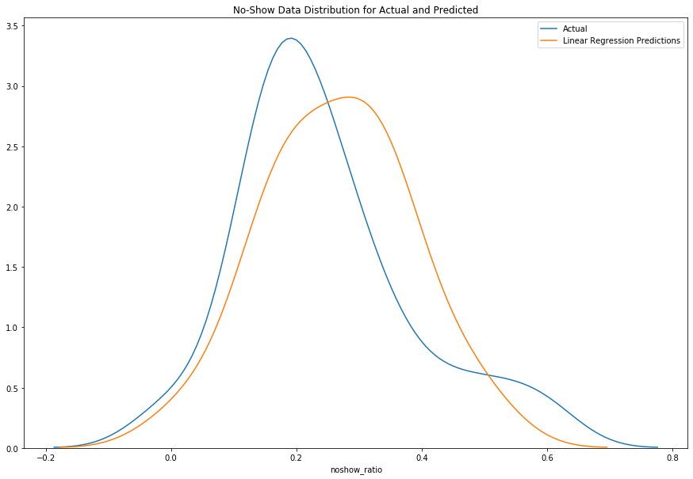

```python
X = factors.drop('noshow_ratio', axis=1)
y = factors['noshow_ratio']

# Split data into Train and Test
X_train, X_test, y_train, y_test = model_selection.train_test_split(X, y, test_size=.3)
X_train['noshow_ratio'] = y_train

# Fit the Linear Regression on Train split
reg = smf.ols(formula='noshow_ratio ~ C(Gender) + C(Scholarship) + C(Hipertension) + \
        C(Diabetes) + C(Alcoholism) + C(SMS_received)', data=X_train).fit()

# Predict using Test split
pred = reg.predict(X_test)

# Plot how the predicted win_ratio compares to actual no show ratio
f, ax = plt.subplots(figsize=(15,10))
plt.title('No-Show Data Distribution for Actual and Predicted')
sns.distplot(y_test, hist=False, label="Actual", ax=ax)
sns.distplot(pred, hist=False, label="Linear Regression Predictions", ax=ax)

plt.show()
```

```python
from scipy.stats import f

# F-Test to evaluate goodness of fit
test = reg.f_test(np.identity(len(reg.params)))
print('Model - Calculated F-Statistic: ' + str(f.ppf(.95,test.df_num,test.df_denom)) + \
        ' F-Value: ' + str(test.fvalue[0][0]) + ' P-Value: ' + str(test.pvalue))
```

```
Model - Calculated F-Statistic: 2.2852351731018694 F-Value: 25.558699414819248 P-Value: 5.603828918192044e-12
```

The F-Value that we produced is greater than the F-Statistic and the P-Value that we produced is less than 0.05. With this information and this model we can say with some confidence that we are able to predict a patients likelihood to not show up to their doctors appointment.From viewing the graph that was created, we can see that these graphs are fairly similar as well.